# 30-exploratory-data-analysis

# What percent of songs that chart never make the Top 10?

For all:

```r
never_top10 <- df %>%
  filter(weeks_top_10 == 0)
nrow(never_top10)/nrow(df)
```

```
[1] 0.6802455
```

Time series:

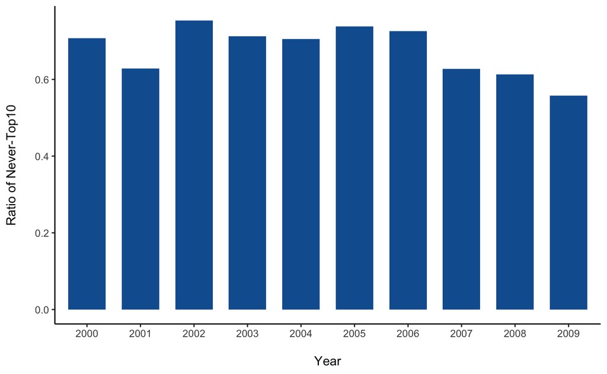

```r
never_top10_year <- df %>%
  filter(weeks_top_10 == 0) %>%
  group_by(year) %>%
  summarise(never_top10_number = n())

all_year <- df %>%
  group_by(year) %>%
  summarise(whole_number = n())

never_top10_year["whole_number"] <- all_year["whole_number"]
never_top10_year %>%
  mutate(never_top10_ratio = never_top10_number/whole_number) %>%
  ggplot() +
  geom_col(aes(x=year, y=never_top10_ratio),fill="#125FA0", width = 0.7)+
  theme_classic()+
  labs(x="\nYear", y="Ratio of Never-Top10\n")
```

# What were the top 10 songs of the decade 2000-2009?

| song_title | artist | weeks_at_number_1 | weeks_top_10 | weeks_top_25 | weeks_top_50 | peak_position | bonus_weeks | sub_points | peak_points | total_points | peak_year | debut_date | peak_date | weeks_to_reach_peak | year |
| --- | --- | --- | --- | --- | --- | --- | --- | --- | --- | --- | --- | --- | --- | --- | --- |
| GLAMOROUS | FERGIE featuring LUDACRIS | 11 | 32 | 40 | 50 | 1 | 9 | 1195 | 140 | 1335 | 2007 | 2007-01-28 | 2007-02-18 | 4 | 2007 |
| BEFORE HE CHEATS | UNDERWOOD, CARRIE | 3 | 42 | 43 | 57 | 1 | 4 | 1052 | 140 | 1192 | 2007 | 2006-11-05 | 2007-06-03 | 31 | 2007 |
| NO SUCH THING | MAYER, JOHN | 13 | 20 | 32 | 42 | 1 | 9 | 1027 | 140 | 1167 | 2002 | 2002-05-26 | 2002-06-23 | 5 | 2002 |
| CITY LOVE | MAYER, JOHN | 10 | 29 | 33 | 37 | 1 | 6 | 1027 | 140 | 1167 | 2003 | 2003-02-16 | 2003-03-30 | 7 | 2003 |
| VIDEO | INDIA.ARIE | 8 | 29 | 34 | 39 | 1 | 7 | 989 | 140 | 1129 | 2002 | 2002-02-17 | 2002-03-24 | 6 | 2002 |
| WHERE IS THE LOVE? | BLACK EYED PEAS featuring JUSTIN TIMBERLAKE | 9 | 27 | 36 | 41 | 1 | 5 | 971 | 140 | 1111 | 2003 | 2003-05-25 | 2003-06-29 | 6 | 2003 |
| TWO WEEKS FROM TWENTY | YELLOWCARD | 8 | 27 | 38 | 46 | 1 | 6 | 971 | 140 | 1111 | 2005 | 2005-07-31 | 2005-09-11 | 7 | 2005 |
| AMERICAN BOY | ESTELLE featuring KANYE WEST | 11 | 26 | 29 | 37 | 1 | 2 | 932 | 140 | 1072 | 2008 | 2008-06-15 | 2008-08-24 | 11 | 2008 |
| TIME OF YOUR LIFE (GOOD RIDDANCE) | GREEN DAY | 0 | 38 | 49 | 65 | 2 | 2 | 910 | 130 | 1040 | 2006 | 2005-09-25 | 2005-12-11 | 12 | 2006 |
| SOMEONE TO CALL MY LOVER | JACKSON, JANET | 10 | 24 | 27 | 32 | 1 | 3 | 872 | 140 | 1012 | 2001 | 2001-07-22 | 2001-07-29 | 2 | 2001 |

[output cut: 990 more lines]

# Who was the top artist of the decade 2000-2009?

Who were the top 10 artists of the decade 2000-2009?

```r
df %>%
  mutate(total_points = as.numeric(total_points)) %>%
  group_by(artist) %>%
  summarise(sum_total_points = sum(total_points, na.rm = TRUE)) %>%
  arrange(desc(sum_total_points)) %>%
  head(10)
```

| artist | sum_total_points |
| --- | --- |
| MAYER, JOHN | 6861 |
| JACKSON, JANET | 6049 |
| PANIC AT THE DISCO | 4572 |
| BLACK EYED PEAS | 4481 |
| CAREY, MARIAH | 4470 |
| GREEN DAY | 4378 |
| CLARKSON, KELLY | 4016 |
| UNDERWOOD, CARRIE | 3762 |
| PINK | 3668 |
| MAROON 5 | 3604 |

# Based on the chart data, what artist(s) would you call “The Beatles” of the decade 2000-2009?

```r
df %>%
  group_by(artist) %>%
  summarise(song_number = n()) %>%
  arrange(desc(song_number))
```

| artist | song_number |
| --- | --- |
| SPEARS, BRITNEY | 21 |
| PINK | 18 |
| CAREY, MARIAH | 14 |
| CLARKSON, KELLY | 14 |
| EMINEM | 14 |
| BEYONCE | 13 |
| LAVIGNE, AVRIL | 13 |
| AGUILERA, CHRISTINA | 12 |
| MAYER, JOHN | 12 |
| NELLY | 12 |

[output cut: 857 more lines]

```r
df %>%
  mutate(total_points = as.numeric(total_points)) %>%
  group_by(artist) %>%
  summarise(mean_total_points = mean(total_points)) %>%
  arrange(desc(mean_total_points))
```

| artist | mean_total_points |
| --- | --- |
| FERGIE featuring LUDACRIS | 1335.00000 |
| BLACK EYED PEAS featuring JUSTIN TIMBERLAKE | 1111.00000 |
| ESTELLE featuring KANYE WEST | 1072.00000 |
| LOS LONELY BOYS | 928.00000 |
| LOPEZ, JENNIFER featuring JA RULE | 861.00000 |
| SHAGGY featuring RICARDO DUCENT | 829.00000 |
| FOXX, JAMIE featuring T-PAIN | 808.00000 |
| POWTER, DANIEL | 779.00000 |
| INDIA.ARIE | 763.50000 |
| EVE featuring GWEN STEFANI | 757.00000 |

[output cut: 857 more lines]

# What was the most commonly used word in a song title for the decade 2000-2009?

clean the special patterns in the title.

```r
title_df <- df["song_title"]
title_df <- title_df %>% mutate(song_title = str_to_lower(song_title))
title_df$song_title <- gsub(pattern = "\\(", replacement =" ", title_df$song_title)
title_df$song_title <- gsub(pattern = "\\)", replacement =" ", title_df$song_title)
title_df$song_title <- gsub(pattern = ",", replacement =" ", title_df$song_title)
title_df$song_title <- gsub(pattern = "n't", replacement =" not ", title_df$song_title)
title_df$song_title <- gsub(pattern = "'s", replacement =" ", title_df$song_title)
title_df$song_title <- gsub(pattern = "'re", replacement =" are ", title_df$song_title)
title_df$song_title <- gsub(pattern = "'m", replacement =" am ", title_df$song_title)
title_df$song_title <- gsub(pattern = "\\\"", replacement =" ", title_df$song_title)
title_df$song_title <- gsub(pattern = "\\.", replacement =" ", title_df$song_title)
title_df$song_title <- gsub(pattern = "-", replacement =" ", title_df$song_title)
title_df$song_title <- gsub(pattern = "_", replacement =" ", title_df$song_title)
title_df$song_title <- gsub(pattern = "!", replacement =" ", title_df$song_title)
title_df$song_title <- gsub(pattern = "\\?", replacement =" ", title_df$song_title)
title_df$song_title <- gsub(pattern = "…", replacement =" ", title_df$song_title)
title_df$song_title <- gsub(pattern = "[0-9]", replacement =" ", title_df$song_title)
title_df$song_title <- gsub(pattern = "/", replacement =" ", title_df$song_title)
title_df$song_title <- gsub(pattern = "&", replacement =" ", title_df$song_title)
title_df$song_title <- gsub(pattern = "#", replacement =" ", title_df$song_title)
title_df$song_title <- gsub(pattern = " +", replacement =" ", title_df$song_title)
```

```r
title_list <- title_df[["song_title"]]
```

Split all of title into scattered words.

```r
title_words <- data.frame()
count <- 1
for (i in title_list) {
  title_split <- str_split(string = i, pattern = " ")
  for(j in title_split[[1]]){
    title_words[count,1] <- j
    count <- count + 1
  }
}
names(title_words) <- "word"
```

clean the different forms of the same word.

```r
title_words <- title_words %>%
  mutate(word = case_when(word == "girls" ~ "girl",
                          word == "angels" ~ "angel",
                          word == "days" ~ "day",
                          word == "lovin'" ~ "love",
                          word == "loving" ~ "love",
                          word == "loved'" ~ "love",
                          word == "luv" ~ "love",
                          word == "waiting" ~ "wait",
                          word == "does" ~ "do",
                          word == "lights" ~ "light",
                          word == "things" ~ "thing",
                          word == "comes" ~ "come",
                          word == "dancing" ~ "dance",
                          word == "dancin'" ~ "dance",
                          word == "boys" ~ "boy",
                          word == "burning" ~ "burn",
                          word == "burnin'" ~ "burn",
                          word == "calle" ~ "call",
                          word == "called" ~ "call",
                          word == "calling" ~ "call",
                          word == "call" ~ "call",
                          TRUE ~ word))
```

Get the number of each word.

[output not shown]

[output cut: 990 more lines]

```r
wordcloud2(head(word_count,100),
           size = 1,
           fontFamily = "Montserrat",
           fontWeight = "Bold",
           minRotation = -pi/6,
           maxRotation = -pi/6,
           rotateRatio = 1,
           color = "#125FA0")
```

[interactive chart not shown]

| word | sentiment |
| --- | --- |
| angel | anticipation |
| angel | joy |
| angel | positive |
| angel | surprise |
| angel | trust |
| professor | positive |
| professor | trust |
| bye | anticipation |
| bye | anticipation |
| bye | anticipation |

[output cut: 990 more lines]

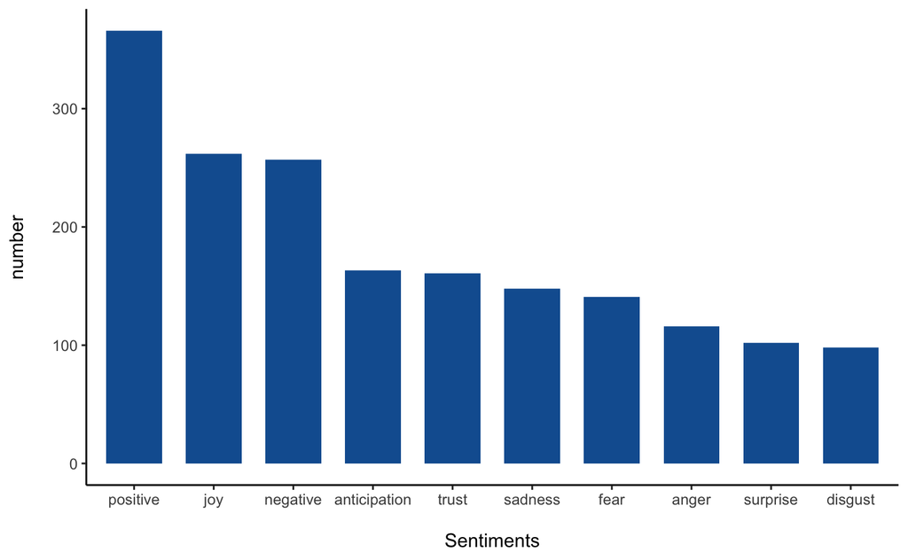

```r
df_sentiments_filtered %>%
  ggplot(aes(x = reorder(sentiment, n, function(n) -n), y = n)) +
  geom_bar(stat = "identity",fill="#125FA0", width = 0.7) +
  theme_classic() +
  # theme(axis.text.x = element_text(angle = 60, hjust = 1)) +
  labs(x = "\nSentiments", y="number\n")
```

```r
words_positive <- df_sentiments %>%
  filter(sentiment == "positive") %>%
  group_by(word) %>%
  summarise(n=n())

words_all_sentiment <- df_sentiments %>%
  filter(!is.na(sentiment)) %>%
  group_by(word) %>%
  summarize(n = n()) %>%
  arrange(desc(n))

nrow(words_positive)/nrow(words_all_sentiment)
```

```
[1] 0.4294671
```

# Who spent the most weeks at #1 for the decade 2000-2009?

```r
df %>%
  group_by(artist) %>%
  summarise(top1_time_sum = sum(weeks_at_number_1)) %>%
  arrange(desc(top1_time_sum)) %>%
  head(1)
```

| artist | top1_time_sum |
| --- | --- |
| JACKSON, JANET | 39 |

# What song spent the most weeks at #1 for the decade 2000-2009?

| song_title | artist | weeks_at_number_1 | weeks_top_10 | weeks_top_25 | weeks_top_50 | peak_position | bonus_weeks | sub_points | peak_points | total_points | peak_year | debut_date | peak_date | weeks_to_reach_peak | year |
| --- | --- | --- | --- | --- | --- | --- | --- | --- | --- | --- | --- | --- | --- | --- | --- |
| NO SUCH THING | MAYER, JOHN | 13 | 20 | 32 | 42 | 1 | 9 | 1027 | 140 | 1167 | 2002 | 2002-05-26 | 2002-06-23 | 5 | 2002 |
| GLAMOROUS | FERGIE featuring LUDACRIS | 11 | 32 | 40 | 50 | 1 | 9 | 1195 | 140 | 1335 | 2007 | 2007-01-28 | 2007-02-18 | 4 | 2007 |
| AMERICAN BOY | ESTELLE featuring KANYE WEST | 11 | 26 | 29 | 37 | 1 | 2 | 932 | 140 | 1072 | 2008 | 2008-06-15 | 2008-08-24 | 11 | 2008 |
| SOMEONE TO CALL MY LOVER | JACKSON, JANET | 10 | 24 | 27 | 32 | 1 | 3 | 872 | 140 | 1012 | 2001 | 2001-07-22 | 2001-07-29 | 2 | 2001 |
| ALL FOR YOU | JACKSON, JANET | 10 | 19 | 25 | 31 | 1 | 6 | 831 | 140 | 971 | 2001 | 2001-03-11 | 2001-04-01 | 4 | 2001 |
| CITY LOVE | MAYER, JOHN | 10 | 29 | 33 | 37 | 1 | 6 | 1027 | 140 | 1167 | 2003 | 2003-02-16 | 2003-03-30 | 7 | 2003 |
| WHERE IS THE LOVE? | BLACK EYED PEAS featuring JUSTIN TIMBERLAKE | 9 | 27 | 36 | 41 | 1 | 5 | 971 | 140 | 1111 | 2003 | 2003-05-25 | 2003-06-29 | 6 | 2003 |
| YEAH | USHER | 9 | 13 | 17 | 31 | 1 | 5 | 656 | 140 | 796 | 2004 | 2004-01-25 | 2004-02-08 | 3 | 2004 |
| DOESN'T REALLY MATTER (from "NUTTY PROFESSOR") | JACKSON, JANET | 8 | 13 | 22 | 25 | 1 | 5 | 645 | 140 | 785 | 2000 | 2000-07-23 | 2000-08-20 | 5 | 2000 |
| VIDEO | INDIA.ARIE | 8 | 29 | 34 | 39 | 1 | 7 | 989 | 140 | 1129 | 2002 | 2002-02-17 | 2002-03-24 | 6 | 2002 |

[output cut: 990 more lines]

# What song peaked at #1 the quickest in the decade 2000-2009?

```r
df %>%
  filter(weeks_at_number_1 != 0) %>%
  arrange(weeks_to_reach_peak) %>%
  select(song_title, artist, year, weeks_at_number_1, weeks_to_reach_peak, debut_date, peak_date) %>%
  head(1)
```

| song_title | artist | year | weeks_at_number_1 | weeks_to_reach_peak | debut_date | peak_date |
| --- | --- | --- | --- | --- | --- | --- |
| SOMEONE TO CALL MY LOVER | JACKSON, JANET | 2001 | 10 | 2 | 2001-07-22 | 2001-07-29 |

# What song took the longest to reach #1 in the decade 2000-2009?

```r
df %>%
  filter(weeks_at_number_1 != 0) %>%
  arrange(desc(weeks_to_reach_peak)) %>%
  select(song_title, artist, year, weeks_at_number_1, weeks_to_reach_peak, debut_date, peak_date) %>%
  head(1)
```

| song_title | artist | year | weeks_at_number_1 | weeks_to_reach_peak | debut_date | peak_date |
| --- | --- | --- | --- | --- | --- | --- |
| BEFORE HE CHEATS | UNDERWOOD, CARRIE | 2007 | 3 | 31 | 2006-11-05 | 2007-06-03 |

# Solo men, solo women, groups for the decade 2000-2009 - design a graphic that shows the distribution of songs hitting #1

```r
df %>%
  mutate(solo_group = case_when(str_detect(string = artist, pattern = ",") ~ "solo",
                                TRUE ~ "group")) %>%
  mutate(solo_group = as.factor(solo_group)) %>%
  filter(weeks_at_number_1 != 0) %>%
  group_by(solo_group) %>%
  summarise(number = n())
```

| solo_group | number |
| --- | --- |
| group | 92 |
| solo | 84 |

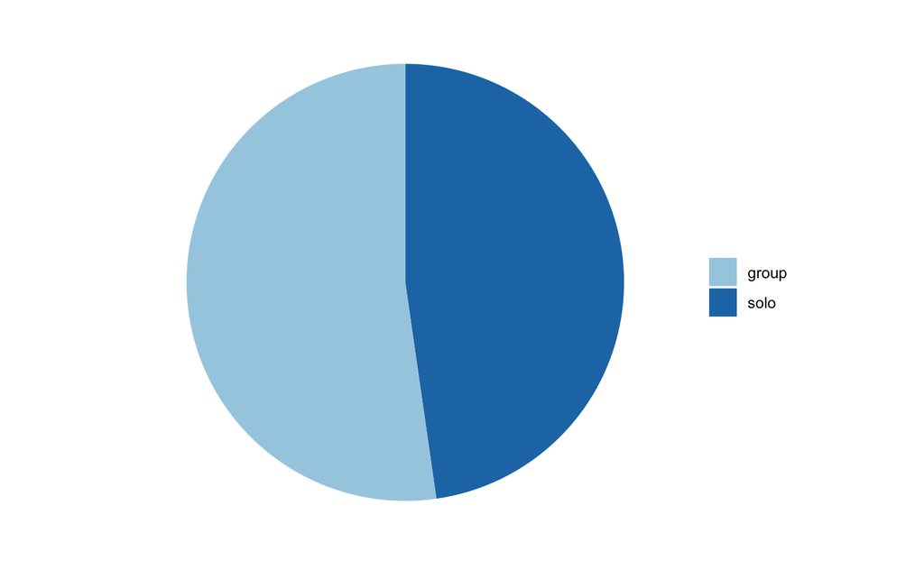

```r
df %>%
  mutate(solo_group = case_when(str_detect(string = artist, pattern = ",") ~ "solo",
                                TRUE ~ "group")) %>%
  mutate(solo_group = as.factor(solo_group)) %>%
  filter(weeks_at_number_1 != 0) %>%
  ggplot()+
  geom_bar(aes(x=1, fill = solo_group))+
  coord_polar(theta = "y")+
  theme(axis.text = element_blank(),
        axis.title = element_blank(),
        axis.ticks = element_blank(),
        axis.line = element_blank(),
        legend.title = element_blank(),
        panel.background = element_blank()
        )+
  scale_fill_brewer(palette = "Paired")
```

# Solo men, solo women, groups for the decade 2000-2009 - design a graphic that shows the distribution of songs hitting the Top 10

```r
df %>%
  mutate(solo_group = case_when(str_detect(string = artist, pattern = ",") ~ "solo",
                                TRUE ~ "group")) %>%
  mutate(solo_group = as.factor(solo_group)) %>%
  filter(weeks_top_10 != 0) %>%
  group_by(solo_group) %>%
  summarise(number = n())
```

| solo_group | number |
| --- | --- |
| group | 318 |
| solo | 255 |

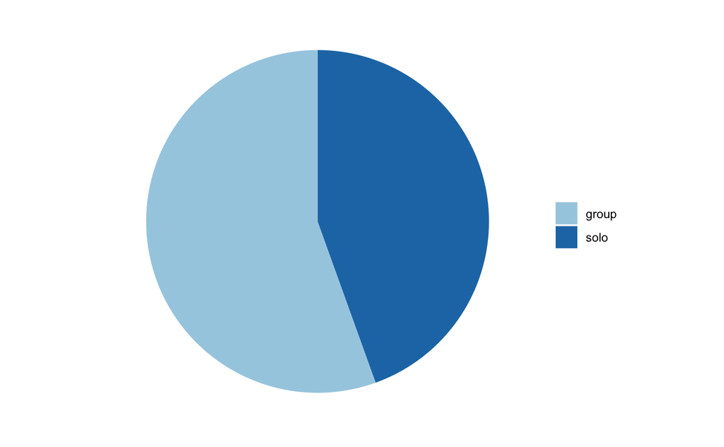

```r
df %>%
  mutate(solo_group = case_when(str_detect(string = artist, pattern = ",") ~ "solo",
                                TRUE ~ "group")) %>%
  mutate(solo_group = as.factor(solo_group)) %>%
  filter(weeks_top_10 != 0) %>%
  ggplot()+
  geom_bar(aes(x=1, fill = solo_group))+
  coord_polar(theta = "y")+
  theme(axis.text = element_blank(),
        axis.title = element_blank(),
        axis.ticks = element_blank(),
        axis.line = element_blank(),
        legend.title = element_blank(),
        panel.background = element_blank()
        )+
  scale_fill_brewer(palette = "Paired")
```

# What song spent the most time on the charts in the decade 2000-2009)

```r
df %>%
  arrange(desc(weeks_top_50)) %>%
  select(song_title, artist, year, weeks_top_50) %>%
  head(3)
```

| song_title | artist | year | weeks_top_50 |
| --- | --- | --- | --- |
| TIME OF YOUR LIFE (GOOD RIDDANCE) | GREEN DAY | 2006 | 65 |
| BEFORE HE CHEATS | UNDERWOOD, CARRIE | 2007 | 57 |
| GLAMOROUS | FERGIE featuring LUDACRIS | 2007 | 50 |

TIME OF YOUR LIFE (GOOD RIDDANCE) never be top 1.

# Is there a correlation between weeks spent on the chart and weeks at #1?

```r
cor(x = df[["weeks_at_number_1"]],
    y = df[["weeks_top_50"]])
```

```
[1] 0.471703
```

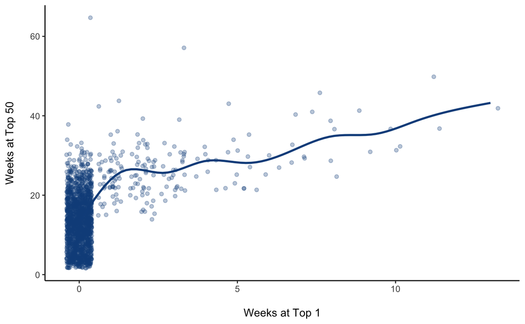

```r
df %>%
  ggplot(aes(x=weeks_at_number_1, y=weeks_top_50))+
  geom_jitter(alpha = 0.3, color = "dodgerblue4")+
  geom_smooth(color = "dodgerblue4", se = FALSE)+
  theme_classic()+
  labs(x="\nWeeks at Top 1", y="Weeks at Top 50\n")
```